# GBR Coral Mortality: Blocked Validation Diagnostics

Baseline models and the path to a BRMS–BRT prediction ensemble

Author

Samuel Matthews

Modified

August 18, 2026

**These are benchmark models, not the final prediction machine**

The explanatory parsimony rule selects linear DHW for manta and MMP, but the prediction-optimal manta benchmark is the full physical-context model. These are reference GLMs, not ecological claims that mortality is truly linear in DHW and not the GBR-wide prediction machine. The formal BRMS and BRT models use the full predictor contract, including preceding-year Acropora, and ensemble their cross-fitted predictions.

# Data and validation design

All modern observations are used in modelling. Each event—including 2024—is held out in turn for temporal validation. Reef-blocked folds test transfer to unseen reefs, while broad region blocks provide a harder geographic stress test. After validation, production models are refitted using every event.

| Programme | Observations | Reefs | Events |
| --- | --- | --- | --- |
| LTMP benthic | 199 | 80 | 2016, 2017, 2020, 2022, 2024 |
| LTMP manta tow | 248 | 110 | 2016, 2017, 2020, 2022, 2024 |
| MMP inshore | 90 | 23 | 2017, 2022, 2024 |

# Candidate model comparison

Five nested hypotheses were evaluated. The comparison adds a preceding-year Acropora composition model to the DHW, nonlinear, optical, and physical-context benchmarks. It tests how much predictive accuracy is gained before moving to the regularised BRMS and BRT frameworks.

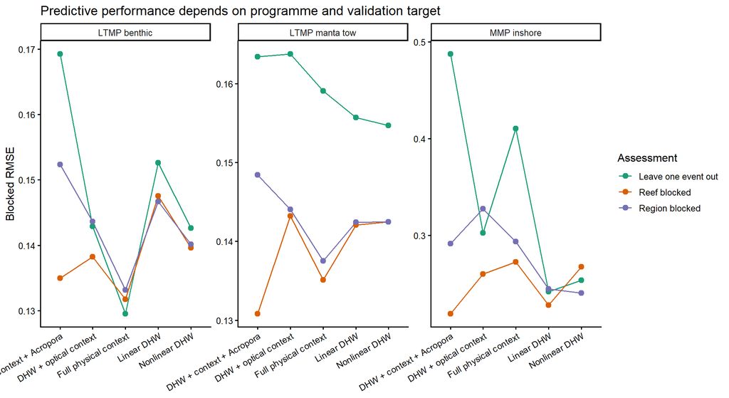

| Programme | Candidate | Complexity | Selection RMSE | Selection MAE | Within 2% | Selected benchmark |
| --- | --- | --- | --- | --- | --- | --- |
| LTMP benthic | Full physical context | 4 | 0.131 | 0.085 | TRUE | TRUE |
| LTMP benthic | DHW + optical context | 3 | 0.141 | 0.096 | FALSE | FALSE |
| LTMP benthic | Nonlinear DHW | 2 | 0.141 | 0.098 | FALSE | FALSE |
| LTMP benthic | Linear DHW | 1 | 0.150 | 0.102 | FALSE | FALSE |
| LTMP benthic | DHW + context + Acropora | 5 | 0.152 | 0.092 | FALSE | FALSE |
| LTMP manta tow | Full physical context | 4 | 0.147 | 0.110 | TRUE | TRUE |
| LTMP manta tow | DHW + context + Acropora | 5 | 0.147 | 0.107 | TRUE | FALSE |
| LTMP manta tow | Nonlinear DHW | 2 | 0.149 | 0.114 | TRUE | FALSE |
| LTMP manta tow | Linear DHW | 1 | 0.149 | 0.115 | TRUE | FALSE |
| LTMP manta tow | DHW + optical context | 3 | 0.154 | 0.117 | FALSE | FALSE |
| MMP inshore | Linear DHW | 1 | 0.235 | 0.169 | TRUE | TRUE |
| MMP inshore | Nonlinear DHW | 2 | 0.261 | 0.181 | FALSE | FALSE |
| MMP inshore | DHW + optical context | 3 | 0.281 | 0.193 | FALSE | FALSE |
| MMP inshore | Full physical context | 4 | 0.341 | 0.244 | FALSE | FALSE |
| MMP inshore | DHW + context + Acropora | 5 | 0.353 | 0.249 | FALSE | FALSE |

# Event-to-event transfer

Leave-one-event-out performance is the most relevant diagnostic for predicting a future bleaching event. The figure below gives each event its own RMSE rather than averaging away difficult years.

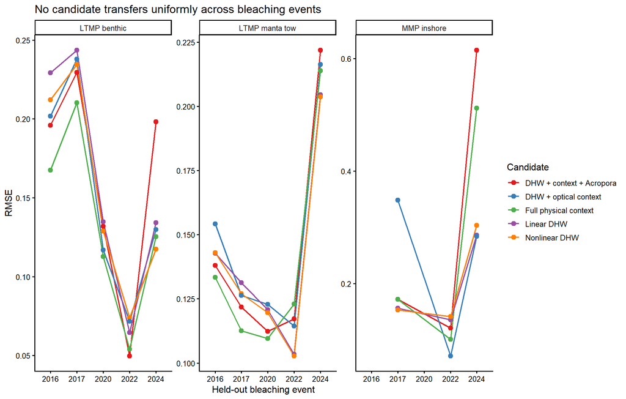

## The 2024 stress test

The widespread 2024 event is retained as a transparent out-of-event test and then included in production fitting. The benchmark models trained on earlier events underpredict mean 2024 mortality, especially for manta and MMP.

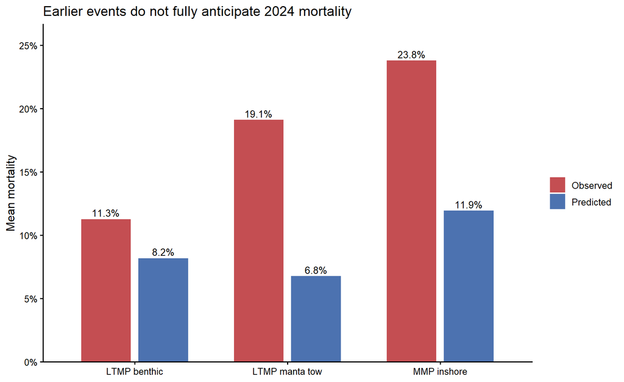

| Programme | Benchmark | N | Observed mean | Predicted mean | RMSE |
| --- | --- | --- | --- | --- | --- |
| LTMP benthic | Full physical context | 75 | 0.113 | 0.082 | 0.125 |
| LTMP manta tow | Full physical context | 89 | 0.191 | 0.068 | 0.214 |
| MMP inshore | Linear DHW | 54 | 0.238 | 0.119 | 0.286 |

# Out-of-fold prediction diagnostics

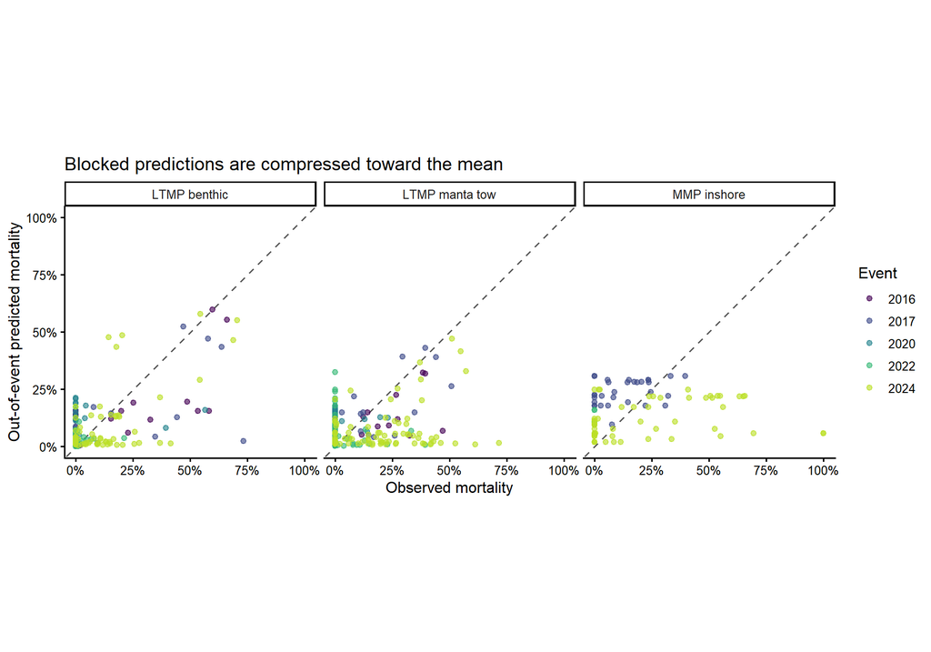

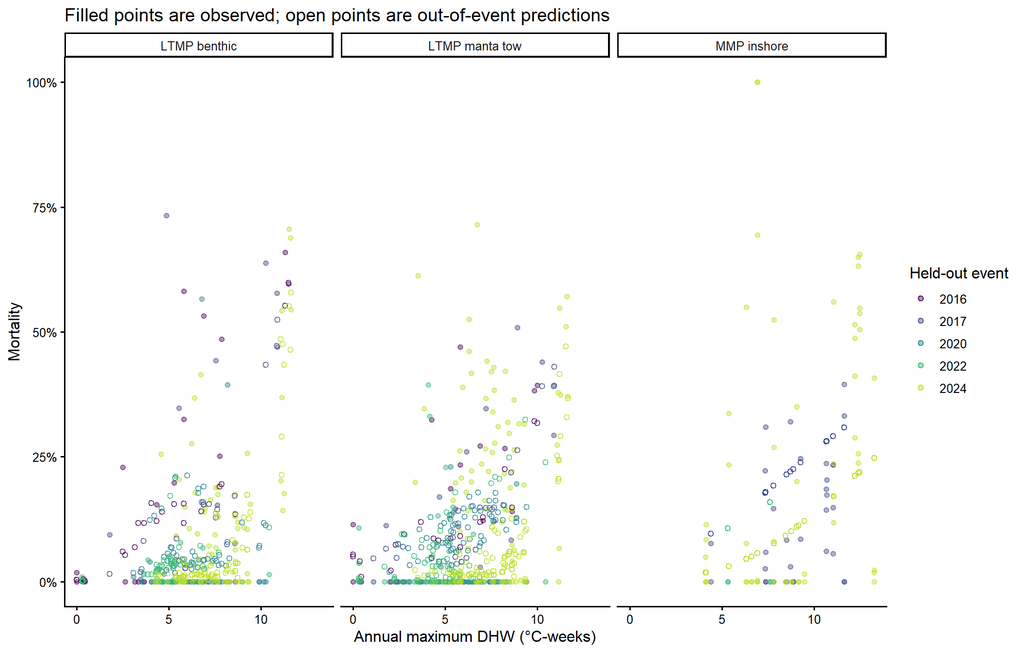

# What the benchmark does—and does not—tell us

- DHW contains transferable signal, but it is not sufficient to reproduce the mortality distribution of an unprecedented event.
- Detailed LTMP benthic observations gain predictive accuracy from physical context, supporting continued environmental modelling.
- MMP cannot support a large standalone environmental model reliably because it has only three event years and nearly half of Secchi values are missing.
- Selection of a linear benchmark for manta or MMP is a statement about the current small candidate comparison and validation variance. It is not a mechanistic dose-response conclusion.

| Programme | Assessment | fold | Candidate | warning |
| --- | --- | --- | --- | --- |
| MMP inshore | Leave one event out | 2024 | DHW + context + Acropora | glm.fit: fitted probabilities numerically 0 or 1 occurred |
| MMP inshore | Leave one event out | 2024 | Full physical context | glm.fit: fitted probabilities numerically 0 or 1 occurred |
| MMP inshore | Region blocked | Central GBR | DHW + context + Acropora | glm.fit: algorithm did not converge |
| MMP inshore | Region blocked | Central GBR | DHW + context + Acropora | glm.fit: fitted probabilities numerically 0 or 1 occurred |
| MMP inshore | Region blocked | Central GBR | DHW + context + Acropora | prediction from rank-deficient fit; attr(*, “non-estim”) has doubtful cases |
| MMP inshore | Region blocked | Central GBR | Full physical context | glm.fit: fitted probabilities numerically 0 or 1 occurred |
| MMP inshore | Region blocked | Central GBR | Full physical context | prediction from rank-deficient fit; attr(*, “non-estim”) has doubtful cases |

# Production prediction architecture

The next comparison should retain the benchmark models but make prediction—not parsimony—the objective:

1. **BRMS base learner:** a hierarchical boundary-aware model with nonlinear DHW, environmental modifiers, event effects, reef/region structure, and full posterior predictive uncertainty.
2. **BRT base learner:** a regularised nonlinear learner using the complete attainable predictor set, with depth and tree number tuned inside each analysis fold.
3. **Cross-fitted ensemble:** obtain BRMS and BRT predictions for every blocked assessment row, estimate non-negative ensemble weights without using that row’s outcome, and compare the ensemble against each base learner and the benchmark.
4. **Full-data refit:** once the architecture and ensemble rule are frozen, refit BRMS and BRT on all events including 2024, then produce GBR-wide means, intervals, and environmental-extrapolation flags.

The extensive cached BRMS and BRT work in `output/models` has not been removed. It remains valuable for model specification and diagnostics, but it must be refitted against the canonical outcomes, reconstructed cloud values, and fixed blocked folds before contributing to the production ensemble.